# forest_041518

Zhenghan Qi

4/18/2018

## Cronbach’s alpha for the simons task

- list L: 0.86; list F: 0.79, average: 0.82

## Cronbach’s alpha for the SLAS task

- 0.97

## Forest Action Analysis

- testing main experimental effects on action
  - significant effect of ambiguity

```r
forest.lmer<- lmer(elog ~ ambcode*refcode  + (1 | subnum) + (0+ambcode|subnum), control = lmerControl(optimizer = "optimx", calc.derivs = FALSE, optCtrl = list(method = "nlminb", starttests = FALSE, kkt = FALSE)), data=forest)
summary(forest.lmer)
```

```
## Linear mixed model fit by REML. t-tests use Satterthwaite's method [
## lmerModLmerTest]
## Formula: elog ~ ambcode * refcode + (1 | subnum) + (0 + ambcode | subnum)
##    Data: forest
## Control:
## lmerControl(optimizer = "optimx", calc.derivs = FALSE, optCtrl = list(method = "nlminb",
##     starttests = FALSE, kkt = FALSE))
##
## REML criterion at convergence: 159
##
## Scaled residuals:
##      Min       1Q   Median       3Q      Max
## -1.00669 -0.39640 -0.01480  0.06237  1.91217
##
## Random effects:
##  Groups   Name        Variance Std.Dev.
##  subnum   (Intercept) 0.4377   0.6616
##  subnum.1 ambcode     1.3203   1.1490
##  Residual             0.9688   0.9843
## Number of obs: 48, groups:  subnum, 24
##
## Fixed effects:
##                 Estimate Std. Error      df t value Pr(>|t|)
## (Intercept)      -1.7756     0.1960 22.0000  -9.059 7.06e-09 ***
## ambcode           1.4731     0.3684 22.0000   3.998 0.000606 ***
## refcode          -0.1907     0.3920 22.0000  -0.486 0.631533
## ambcode:refcode  -0.5923     0.7369 22.0000  -0.804 0.430146
## ---
## Signif. codes:  0 '***' 0.001 '**' 0.01 '*' 0.05 '.' 0.1 ' ' 1
##
## Correlation of Fixed Effects:
##             (Intr) ambcod refcod
## ambcode     0.000
## refcode     0.000  0.000
## ambcod:rfcd 0.000  0.000  0.000
```

- plot the ambiguity by referential context interaction

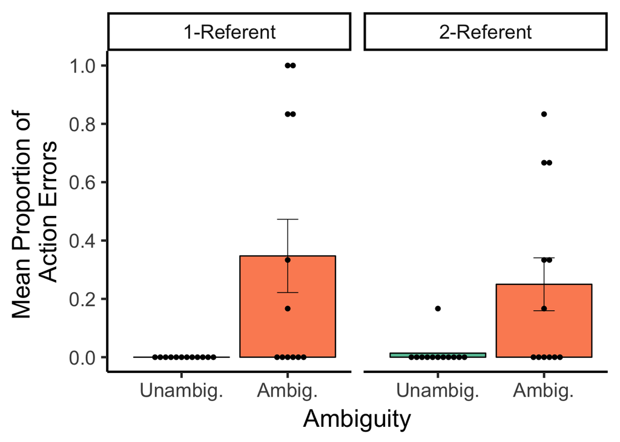

```r
forest$errorprop = forest$actionError/6
levels(forest$ref) = c("1-Referent","2-Referent")
ggplot() +
  theme_classic(base_size = 20.0) +
  ylab(label = 'Mean Proportion of \nAction Errors') +
  scale_y_continuous(breaks = pretty_breaks(),limits = c(0,1)) +
  geom_bar(aes(y = errorprop, x = amb,fill = as.factor(amb)),data=forest,colour="black",fun.data = mean_sdl,stat = 'summary') +
  geom_beeswarm(aes(x = amb,y = errorprop),data=forest,dodge.width=0.9,cex=2.5) +
  geom_errorbar(aes(y = errorprop, x = amb),data=forest,size = 0.3,width = 0.2,fun.y = function(x) mean(x),fun.ymin = function(x) mean(x) - sd(x)/sqrt(length(x)),fun.ymax = function(x) mean(x) + sd(x)/sqrt(length(x)) ,stat = 'summary')+
  facet_wrap(facets = ~ref) +
  scale_x_discrete(name = 'Ambiguity',breaks = c("1","0"),labels = c("Ambig.","Unambig."))+
  scale_fill_brewer(palette = 'Set2') +
  theme(legend.position = "none")
```

- get subject-specific ambiguity effect on action

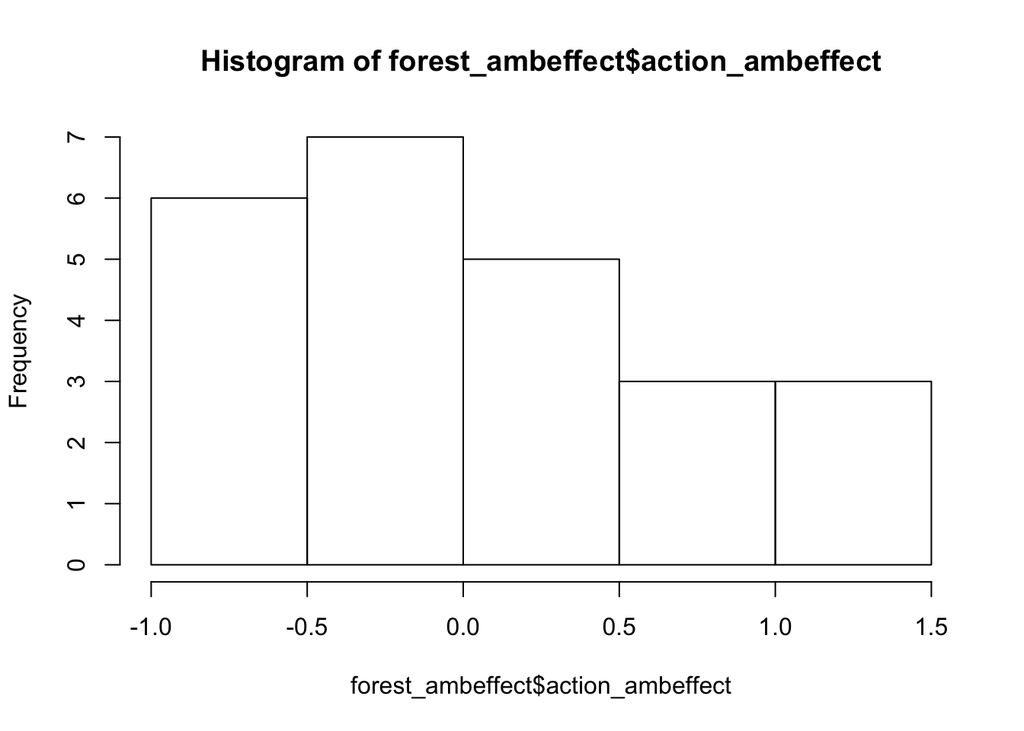

```r
forest_ambeffect=ranef(forest.lmer)$subnum[2]
forest_ambeffect <- cbind(forest_ambeffect,forest_id)
colnames(forest_ambeffect)[2] = "subnum"
colnames(forest_ambeffect)[1] = "action_ambeffect"
hist(forest_ambeffect$action_ambeffect)
```

## Analysis of Fixation

- autoregreesive generalized mixed effect models of DD1 with only the experimental factors
  - no significant effect

```r
forest_dd1_ar1 <- read.delim("~/Dropbox (Personal)/CindyLab/EnchantedForest/Forest_Writing/forest_n2_onset.txt",check.names=FALSE)
forest_dd1_ar1 <- subset(forest_dd1_ar1,Subnum %in% forest_id)
forest_dd1_ar1 <- subset(forest_dd1_ar1,Drop!="drop")
forest_dd1_ar1 <- melt(forest_dd1_ar1,id = c(1:6))
colnames(forest_dd1_ar1)[7]="time"
colnames(forest_dd1_ar1)[8]="looks"
forest_dd1_ar1$ddlooks = ifelse(forest_dd1_ar1$looks=="DD",1,0)
forest_dd1_ar1 = forest_dd1_ar1[order(forest_dd1_ar1$Subnum,forest_dd1_ar1$Trial,forest_dd1_ar1$time),]
# add a column of dd looks with 1 timepoints of lag.
forest_dd1_ar1$ddlag1=NA
for (s in forest_id){
  s_trial <- unique(forest_dd1_ar1[forest_dd1_ar1$Subnum==s,]$Trial)
  for (t in s_trial){
    i = which(forest_dd1_ar1$Subnum==s & forest_dd1_ar1$Trial==t)
    for (ix in i[-1]){
      forest_dd1_ar1$ddlag1[ix] = forest_dd1_ar1$ddlooks[ix-1]
    }
  }
}
forest_dd1_ar1 = subset(forest_dd1_ar1,time!=167)
forest_dd1_ar1$ambcode <- ifelse(forest_dd1_ar1$Amb==0,-.5,.5)
forest_dd1_ar1$refcode<- ifelse(forest_dd1_ar1$Ref==1,-.5,.5)
dd1.lmer.ar1 <- glmer(ddlooks ~ 1 + ddlag1 + ambcode*refcode + (-1+ddlag1+ambcode|Subnum) + (1+ddlag1+ambcode*refcode|Trial), family = binomial,control=glmerControl(optimizer="bobyqa", optCtrl=list(maxfun=2e5)),data = forest_dd1_ar1)
summary(dd1.lmer.ar1)
```

```
## Generalized linear mixed model fit by maximum likelihood (Laplace
##   Approximation) [glmerMod]
##  Family: binomial  ( logit )
## Formula:
## ddlooks ~ 1 + ddlag1 + ambcode * refcode + (-1 + ddlag1 + ambcode |
##     Subnum) + (1 + ddlag1 + ambcode * refcode | Trial)
##    Data: forest_dd1_ar1
## Control:
## glmerControl(optimizer = "bobyqa", optCtrl = list(maxfun = 2e+05))
##
##      AIC      BIC   logLik deviance df.resid
##   1420.3   1587.5   -687.1   1374.3    10617
##
## Scaled residuals:
##     Min      1Q  Median      3Q     Max
## -5.3168 -0.0962 -0.0891 -0.0788 13.5791
##
## Random effects:
##  Groups Name            Variance  Std.Dev.  Corr
##  Subnum ddlag1          7.223e-16 2.688e-08
##         ambcode         1.732e-12 1.316e-06 -1.00
##  Trial  (Intercept)     1.053e-01 3.245e-01
##         ddlag1          2.787e-03 5.279e-02 -1.00
##         ambcode         2.214e-02 1.488e-01 -1.00  1.00
##         refcode         4.178e-02 2.044e-01  1.00 -1.00 -1.00
##         ambcode:refcode 6.162e-05 7.850e-03 -1.00  1.00  1.00 -1.00
## Number of obs: 10640, groups:  Subnum, 24; Trial, 12
##
## Fixed effects:
##                 Estimate Std. Error z value Pr(>|z|)
## (Intercept)     -4.81643    0.15200 -31.686   <2e-16 ***
## ddlag1           7.61961    0.18196  41.875   <2e-16 ***
## ambcode          0.06312    0.18876   0.334    0.738
## refcode         -0.20014    0.19432  -1.030    0.303
## ambcode:refcode -0.01062    0.36921  -0.029    0.977
## ---
## Signif. codes:  0 '***' 0.001 '**' 0.01 '*' 0.05 '.' 0.1 ' ' 1
##
## Correlation of Fixed Effects:
##             (Intr) ddlag1 ambcod refcod
## ddlag1      -0.541
## ambcode     -0.222  0.003
## refcode      0.266 -0.008 -0.145
## ambcod:rfcd -0.012 -0.051  0.115 -0.109
```

- autoregreesive generalized mixed effect models of DD2 with only the experimental factors
  - significant effect of ambiguity and significant interaction between ambiguity and referential context.

```r
forest_dd2_ar1 <- read.delim("~/Dropbox (Personal)/CindyLab/EnchantedForest/Forest_Writing/forest_n2_onset2.txt",check.names=FALSE)
forest_dd2_ar1 <- subset(forest_dd2_ar1,Subnum %in% forest_id)
forest_dd2_ar1 <- subset(forest_dd2_ar1,Drop!="drop")
forest_dd2_ar1 <- melt(forest_dd2_ar1,id = c(1:6))
colnames(forest_dd2_ar1)[7]="time"
colnames(forest_dd2_ar1)[8]="looks"
forest_dd2_ar1$ddlooks = ifelse(forest_dd2_ar1$looks=="DD",1,0)
forest_dd2_ar1 = forest_dd2_ar1[order(forest_dd2_ar1$Subnum,forest_dd2_ar1$Trial,forest_dd2_ar1$time),]
# add a column of dd looks with 1 timepoints of lag.
forest_dd2_ar1$ddlag1=NA
for (s in forest_id){
  s_trial <- unique(forest_dd2_ar1[forest_dd2_ar1$Subnum==s,]$Trial)
  for (t in s_trial){
    i = which(forest_dd2_ar1$Subnum==s & forest_dd2_ar1$Trial==t)
    for (ix in i[-1]){
      forest_dd2_ar1$ddlag1[ix] = forest_dd2_ar1$ddlooks[ix-1]
    }
  }
}
forest_dd2_ar1 = subset(forest_dd2_ar1,time!=1500)
forest_dd2_ar1$ambcode <- ifelse(forest_dd2_ar1$Amb==0,-.5,.5)
forest_dd2_ar1$refcode<- ifelse(forest_dd2_ar1$Ref==1,-.5,.5)
dd2.lmer.ar1 <- glmer(ddlooks ~ 1 + ddlag1 + ambcode*refcode + (1+ddlag1+ambcode|Subnum) + (1+ddlag1+ambcode*refcode|Trial), family = binomial,control=glmerControl(optimizer="bobyqa", optCtrl=list(maxfun=2e5)),data = forest_dd2_ar1)
summary(dd2.lmer.ar1)
```

```
## Generalized linear mixed model fit by maximum likelihood (Laplace
##   Approximation) [glmerMod]
##  Family: binomial  ( logit )
## Formula:
## ddlooks ~ 1 + ddlag1 + ambcode * refcode + (1 + ddlag1 + ambcode |
##     Subnum) + (1 + ddlag1 + ambcode * refcode | Trial)
##    Data: forest_dd2_ar1
## Control:
## glmerControl(optimizer = "bobyqa", optCtrl = list(maxfun = 2e+05))
##
##      AIC      BIC   logLik deviance df.resid
##   1024.9   1214.6   -486.4    972.9    10880
##
## Scaled residuals:
##     Min      1Q  Median      3Q     Max
## -4.8252 -0.0679 -0.0546 -0.0395 21.5075
##
## Random effects:
##  Groups Name            Variance  Std.Dev. Corr
##  Subnum (Intercept)     4.790e-01 0.692109
##         ddlag1          2.512e-01 0.501180 -1.00
##         ambcode         2.807e-04 0.016755 -1.00  1.00
##  Trial  (Intercept)     3.536e-01 0.594616
##         ddlag1          3.638e-01 0.603185 -1.00
##         ambcode         1.272e-01 0.356693 -1.00  1.00
##         refcode         4.313e-06 0.002077  1.00 -1.00 -1.00
##         ambcode:refcode 5.247e-01 0.724342  1.00 -1.00 -1.00  1.00
## Number of obs: 10906, groups:  Subnum, 24; Trial, 12
##
## Fixed effects:
##                 Estimate Std. Error z value Pr(>|z|)
## (Intercept)      -5.9513     0.3272 -18.190   <2e-16 ***
## ddlag1            8.0008     0.3334  23.997   <2e-16 ***
## ambcode           0.5873     0.2896   2.028   0.0426 *
## refcode           0.1559     0.2862   0.545   0.5859
## ambcode:refcode  -1.3192     0.5428  -2.431   0.0151 *
## ---
## Signif. codes:  0 '***' 0.001 '**' 0.01 '*' 0.05 '.' 0.1 ' ' 1
##
## Correlation of Fixed Effects:
##             (Intr) ddlag1 ambcod refcod
## ddlag1      -0.883
## ambcode     -0.357  0.284
## refcode     -0.070 -0.005  0.291
## ambcod:rfcd  0.376 -0.237 -0.312 -0.186
```

- simple effect of ambiguity in the 1-referent group: significant ambiguity effect

```r
forest_dd2_ar1$Ref = as.factor(as.character(forest_dd2_ar1$Ref))
levels(forest_dd2_ar1$Ref)
```

```
## [1] "1" "2"
```

```r
forest_dd2_ar1$ref1_code = 0
forest_dd2_ar1[forest_dd2_ar1$Ref=="2",]$ref1_code = 1
dd2.lmer.ar1.1ref <- glmer(ddlooks ~ 1 + ddlag1 + ambcode*ref1_code + (1+ddlag1+ambcode|Subnum) + (1+ddlag1+ambcode*ref1_code|Trial), family = binomial,control=glmerControl(optimizer="bobyqa", optCtrl=list(maxfun=2e5)),data = forest_dd2_ar1)
summary(dd2.lmer.ar1.1ref)
```

```
## Generalized linear mixed model fit by maximum likelihood (Laplace
##   Approximation) [glmerMod]
##  Family: binomial  ( logit )
## Formula:
## ddlooks ~ 1 + ddlag1 + ambcode * ref1_code + (1 + ddlag1 + ambcode |
##     Subnum) + (1 + ddlag1 + ambcode * ref1_code | Trial)
##    Data: forest_dd2_ar1
## Control:
## glmerControl(optimizer = "bobyqa", optCtrl = list(maxfun = 2e+05))
##
##      AIC      BIC   logLik deviance df.resid
##   1024.9   1214.6   -486.4    972.9    10880
##
## Scaled residuals:
##     Min      1Q  Median      3Q     Max
## -4.8252 -0.0679 -0.0546 -0.0395 21.5073
##
## Random effects:
##  Groups Name              Variance  Std.Dev. Corr
##  Subnum (Intercept)       4.790e-01 0.692103
##         ddlag1            2.512e-01 0.501175 -1.00
##         ambcode           2.808e-04 0.016756 -1.00  1.00
##  Trial  (Intercept)       3.523e-01 0.593553
##         ddlag1            3.638e-01 0.603174 -1.00
##         ambcode           5.167e-01 0.718802 -1.00  1.00
##         ref1_code         4.354e-06 0.002087  1.00 -1.00 -1.00
##         ambcode:ref1_code 5.246e-01 0.724258  1.00 -1.00 -1.00  1.00
## Number of obs: 10906, groups:  Subnum, 24; Trial, 12
##
## Fixed effects:
##                   Estimate Std. Error z value Pr(>|z|)
## (Intercept)        -6.0292     0.3656 -16.490  < 2e-16 ***
## ddlag1              8.0008     0.3330  24.027  < 2e-16 ***
## ambcode             1.2468     0.4535   2.749  0.00597 **
## ref1_code           0.1559     0.2860   0.545  0.58569
## ambcode:ref1_code  -1.3191     0.5416  -2.436  0.01487 *
## ---
## Signif. codes:  0 '***' 0.001 '**' 0.01 '*' 0.05 '.' 0.1 ' ' 1
##
## Correlation of Fixed Effects:
##             (Intr) ddlag1 ambcod rf1_cd
## ddlag1      -0.787
## ambcode     -0.518  0.322
## ref1_code   -0.453 -0.006  0.295
## ambcd:rf1_c  0.407 -0.236 -0.795 -0.185
```

- simple effect of ambiguity in the 2-referent group: non-significant ambiguity effect

```r
forest_dd2_ar1$ref2_code = 1
forest_dd2_ar1[forest_dd2_ar1$Ref=="2",]$ref2_code = 0
dd2.lmer.ar1.2ref <- glmer(ddlooks ~ 1 + ddlag1 + ambcode*ref2_code + (1+ddlag1+ambcode|Subnum) + (1+ddlag1+ambcode*ref2_code|Trial), family = binomial,control=glmerControl(optimizer="bobyqa", optCtrl=list(maxfun=2e5)),data = forest_dd2_ar1)
summary(dd2.lmer.ar1.2ref)
```

```
## Generalized linear mixed model fit by maximum likelihood (Laplace
##   Approximation) [glmerMod]
##  Family: binomial  ( logit )
## Formula:
## ddlooks ~ 1 + ddlag1 + ambcode * ref2_code + (1 + ddlag1 + ambcode |
##     Subnum) + (1 + ddlag1 + ambcode * ref2_code | Trial)
##    Data: forest_dd2_ar1
## Control:
## glmerControl(optimizer = "bobyqa", optCtrl = list(maxfun = 2e+05))
##
##      AIC      BIC   logLik deviance df.resid
##   1024.9   1214.6   -486.4    972.9    10880
##
## Scaled residuals:
##     Min      1Q  Median      3Q     Max
## -4.8253 -0.0679 -0.0546 -0.0395 21.5075
##
## Random effects:
##  Groups Name              Variance  Std.Dev. Corr
##  Subnum (Intercept)       4.790e-01 0.692101
##         ddlag1            2.512e-01 0.501171 -1.00
##         ambcode           2.804e-04 0.016747 -1.00  1.00
##  Trial  (Intercept)       3.548e-01 0.595651
##         ddlag1            3.638e-01 0.603179 -1.00
##         ambcode           3.008e-05 0.005484  1.00 -1.00
##         ref2_code         4.342e-06 0.002084 -1.00  1.00 -1.00
##         ambcode:ref2_code 5.247e-01 0.724338 -1.00  1.00 -1.00  1.00
## Number of obs: 10906, groups:  Subnum, 24; Trial, 12
##
## Fixed effects:
##                   Estimate Std. Error z value Pr(>|z|)
## (Intercept)       -5.87329    0.34748 -16.903   <2e-16 ***
## ddlag1             8.00077    0.33308  24.020   <2e-16 ***
## ambcode           -0.07233    0.32922  -0.220   0.8261
## ref2_code         -0.15591    0.28609  -0.545   0.5858
## ambcode:ref2_code  1.31918    0.54203   2.434   0.0149 *
## ---
## Signif. codes:  0 '***' 0.001 '**' 0.01 '*' 0.05 '.' 0.1 ' ' 1
##
## Correlation of Fixed Effects:
##             (Intr) ddlag1 ambcod rf2_cd
## ddlag1      -0.833
## ambcode      0.038  0.055
## ref2_code   -0.346  0.006 -0.103
## ambcd:rf2_c -0.277  0.236 -0.549 -0.185
```

- plot ambiguity x referential context interaction on distractor destination fixation (late window)

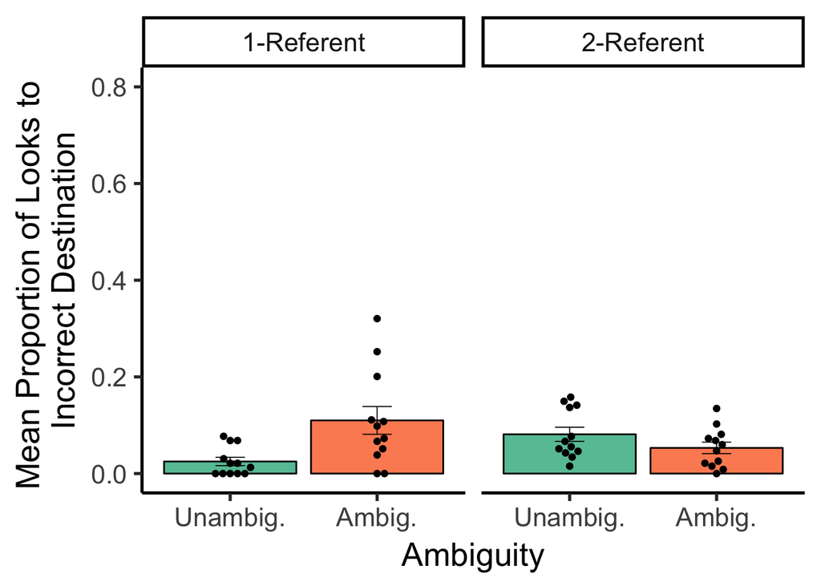

```r
forest_DD2 = cast(forest_data2,subnum+amb+ref~.,value="DD2",mean)
colnames(forest_DD2)[4]="DD2"
levels(forest_DD2$ref) = c("1-Referent","2-Referent")
ggplot() +
  theme_classic(base_size = 20.0) +
  ylab(label = 'Mean Proportion of Looks to \nIncorrect Destination') +
  scale_y_continuous(breaks = pretty_breaks(),limits = c(0,.8)) +
  geom_bar(aes(y = DD2, x = amb,fill = as.factor(amb)),data=forest_DD2,colour="black",fun.data = mean_sdl,stat = 'summary') +
  geom_beeswarm(aes(x = amb,y = DD2),data=forest_DD2,dodge.width=0.9,cex=2.5) +
  geom_errorbar(aes(y = DD2, x = amb),data=forest_DD2,size = 0.3,width = 0.2,fun.y = function(x) mean(x),fun.ymin = function(x) mean(x) - sd(x)/sqrt(length(x)),fun.ymax = function(x) mean(x) + sd(x)/sqrt(length(x)) ,stat = 'summary')+
  facet_wrap(facets = ~ref) +
  scale_x_discrete(name = 'Ambiguity',breaks = c("1","0"),labels = c("Ambig.","Unambig."))+
  scale_fill_brewer(palette = 'Set2') +
  theme(legend.position = "none")
```

- get subject-specific ambiguity effect on DD2

```r
dd2_ambeffect = ranef(dd2.lmer.ar1)$Subnum[3]
dd2_ambeffect = cbind(dd2_ambeffect,forest_id)
dd2_se_ambeffect = se.ranef(dd2.lmer.ar1)$Subnum[,3]
dd2_ambeffect = cbind(dd2_se_ambeffect,dd2_ambeffect)
dd2_intercept = ranef(dd2.lmer.ar1)$Subnum[1]
dd2_ambeffect = cbind (dd2_intercept,dd2_ambeffect)
colnames(dd2_ambeffect)= c("intercept","dd2_se_ambeffect","dd2_ambeffect","subnum")
```

- get reliablity measure for DD2 fixation ** reliability for dd2 is:

```r
dd2_ambeffect$dd2_se_sq = (dd2_ambeffect$dd2_se_ambeffect)^2
dd2_reliability = (var(dd2_ambeffect$intercept) - mean(dd2_ambeffect$dd2_se_sq))/var(dd2_ambeffect$intercept)
print(dd2_reliability)
```

```
## [1] 0.9992684
```

- autoregreesive generalized mixed effect models of TDinto with only the experimental factors
  - significant ambiguity effect.

```r
forest_td2_ar1 <- read.delim("~/Dropbox (Personal)/CindyLab/EnchantedForest/Forest_Writing/forest_into_onset.txt",check.names=FALSE)
forest_td2_ar1 <- subset(forest_td2_ar1,Subnum %in% forest_id)
forest_td2_ar1 <- subset(forest_td2_ar1,Drop!="drop")
forest_td2_ar1 <- melt(forest_td2_ar1,id = c(1:6))
colnames(forest_td2_ar1)[7]="time"
colnames(forest_td2_ar1)[8]="looks"
forest_td2_ar1$tdlooks = ifelse(forest_td2_ar1$looks=="TD",1,0)
forest_td2_ar1 = forest_td2_ar1[order(forest_td2_ar1$Subnum,forest_td2_ar1$Trial,forest_td2_ar1$time),]
# add a column of dd looks with 1 timepoints of lag.
forest_td2_ar1$tdlag1=NA
for (s in forest_id){
  s_trial <- unique(forest_td2_ar1[forest_td2_ar1$Subnum==s,]$Trial)
  for (t in s_trial){
    i = which(forest_td2_ar1$Subnum==s & forest_td2_ar1$Trial==t)
    for (ix in i[-1]){
      forest_td2_ar1$tdlag1[ix] = forest_td2_ar1$tdlooks[ix-1]
    }
  }
}
forest_td2_ar1$ambcode <- ifelse(forest_td2_ar1$Amb==0,-.5,.5)
forest_td2_ar1$refcode<- ifelse(forest_td2_ar1$Ref==1,-.5,.5)
forest_td2_ar1 = subset(forest_td2_ar1,time!= 167)
td2.lmer.ar1 <- glmer(tdlooks ~ 1 + tdlag1 + ambcode*refcode + (1+tdlag1+ambcode|Subnum) + (1+tdlag1+ambcode+refcode|Trial), family = binomial,control=glmerControl(optimizer="bobyqa", optCtrl=list(maxfun=2e5)),data = forest_td2_ar1)
summary(td2.lmer.ar1)
```

```
## Generalized linear mixed model fit by maximum likelihood (Laplace
##   Approximation) [glmerMod]
##  Family: binomial  ( logit )
## Formula:
## tdlooks ~ 1 + tdlag1 + ambcode * refcode + (1 + tdlag1 + ambcode |
##     Subnum) + (1 + tdlag1 + ambcode + refcode | Trial)
##    Data: forest_td2_ar1
## Control:
## glmerControl(optimizer = "bobyqa", optCtrl = list(maxfun = 2e+05))
##
##      AIC      BIC   logLik deviance df.resid
##   3064.8   3224.2  -1511.4   3022.8    14609
##
## Scaled residuals:
##     Min      1Q  Median      3Q     Max
## -7.3172 -0.1417 -0.1176  0.1447 10.7041
##
## Random effects:
##  Groups Name        Variance  Std.Dev. Corr
##  Subnum (Intercept) 0.0776455 0.27865
##         tdlag1      0.0005847 0.02418  1.00
##         ambcode     0.0042099 0.06488  1.00  1.00
##  Trial  (Intercept) 0.1405114 0.37485
##         tdlag1      0.0540551 0.23250  -0.98
##         ambcode     0.0014952 0.03867   0.16 -0.34
##         refcode     0.0173827 0.13184   0.25 -0.42  1.00
## Number of obs: 14630, groups:  Subnum, 24; Trial, 12
##
## Fixed effects:
##                  Estimate Std. Error z value Pr(>|z|)
## (Intercept)     -3.997025   0.143460 -27.862  < 2e-16 ***
## tdlag1           7.312218   0.138317  52.866  < 2e-16 ***
## ambcode         -0.350207   0.120891  -2.897  0.00377 **
## refcode         -0.002524   0.170694  -0.015  0.98820
## ambcode:refcode  0.105830   0.231754   0.457  0.64792
## ---
## Signif. codes:  0 '***' 0.001 '**' 0.01 '*' 0.05 '.' 0.1 ' ' 1
##
## Correlation of Fixed Effects:
##             (Intr) tdlag1 ambcod refcod
## tdlag1      -0.622
## ambcode      0.076  0.042
## refcode      0.039 -0.048  0.041
## ambcod:rfcd  0.017 -0.015 -0.042  0.121
```

- plot significant ambiguity effect on target destination fixation (into)

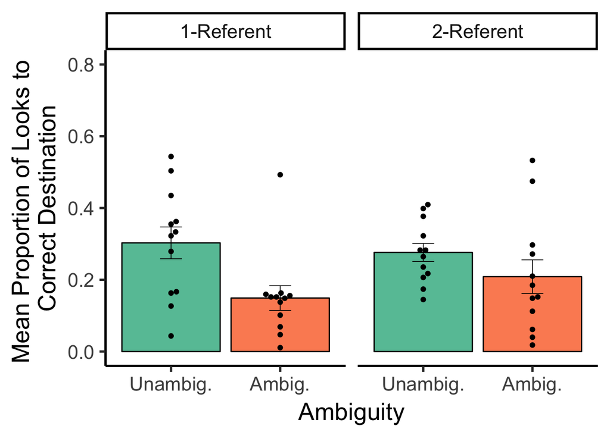

```r
forest_TD2 = cast(forest_data,subnum+amb+ref~.,value="Tdinto",mean)
colnames(forest_TD2)[4]="Tdinto"
levels(forest_TD2$ref) = c("1-Referent","2-Referent")
ggplot() +
  theme_classic(base_size = 20.0) +
  ylab(label = 'Mean Proportion of Looks to \nCorrect Destination') +
  scale_y_continuous(breaks = pretty_breaks(),limits = c(0,0.8)) +
  geom_bar(aes(y = Tdinto, x = amb,fill = as.factor(amb)),data=forest_TD2,colour="black",fun.data = mean_sdl,stat = 'summary') +
  geom_beeswarm(aes(x = amb,y = Tdinto),data=forest_TD2,dodge.width=0.9,cex=2.5) +
  geom_errorbar(aes(y = Tdinto, x = amb),data=forest_TD2,size = 0.3,width = 0.2,fun.y = function(x) mean(x),fun.ymin = function(x) mean(x) - sd(x)/sqrt(length(x)),fun.ymax = function(x) mean(x) + sd(x)/sqrt(length(x)) ,stat = 'summary')+
  facet_wrap(facets = ~ref) +
  scale_x_discrete(name = 'Ambiguity',breaks = c("1","0"),labels = c("Ambig.","Unambig."))+
  scale_fill_brewer(palette = 'Set2') +
  theme(legend.position = "none")
```

- get subject-specific ambiguity effect on TD2

```r
td2_ambeffect = ranef(td2.lmer.ar1)$Subnum[3]
td2_ambeffect = cbind(td2_ambeffect,forest_id)
td2_se_ambeffect = se.ranef(td2.lmer.ar1)$Subnum[,3]
td2_ambeffect = cbind(td2_se_ambeffect,td2_ambeffect)
td2_intercept = ranef(td2.lmer.ar1)$Subnum[1]
td2_ambeffect = cbind (td2_intercept,td2_ambeffect)
colnames(td2_ambeffect)= c("intercept","td2_se_ambeffect","td2_ambeffect","subnum")
```

- get reliablity measure for TD2 fixation ** reliability for td2 is

```r
td2_ambeffect$td2_se_sq = (td2_ambeffect$td2_se_ambeffect)^2
td2_reliability = (var(td2_ambeffect$intercept) - mean(td2_ambeffect$td2_se_sq))/var(td2_ambeffect$intercept)
print(td2_reliability)
```

```
## [1] 0.9464556
```

## individual difference analysis

- testing the spearman correlation between ambeffect and individual difference measures
  - we did not report digit span measure in the paper, because there are 6 children who did not complete the digit span. Also this was a forward digit span task, which is more related to verbal short term memory than working memory.
- list correlation rho values
  - simon says scores are significantly correlated with ambiguity effect on action.

```
##                    Age    SimonSays        SLAT      Action         DD2
## Age        1.000000000 -0.002280465  0.16162790 -0.03734454  0.02522288
## SimonSays -0.002280465  1.000000000  0.21184529 -0.42216405  0.16415782
## SLAT       0.161627901  0.211845291  1.00000000 -0.24449495  0.01579817
## Action    -0.037344540 -0.422164054 -0.24449495  1.00000000 -0.61505678
## DD2        0.025222875  0.164157816  0.01579817 -0.61505678  1.00000000
## TD2       -0.134811919  0.206565252 -0.06590096 -0.36010867  0.57826087
##                   TD2
## Age       -0.13481192
## SimonSays  0.20656525
## SLAT      -0.06590096
## Action    -0.36010867
## DD2        0.57826087
## TD2        1.00000000
```

- list correlation p values (one-sided)

```
##                 Age  SimonSays      SLAT       Action          DD2
## Age       0.5000000 0.49578105 0.2252673 0.4312299959 0.4534347276
## SimonSays 0.4957811 0.50000000 0.1601695 0.0199411778 0.2216904908
## SLAT      0.2252673 0.16016945 0.5000000 0.1247808928 0.4707965849
## Action    0.4312300 0.01994118 0.1247809 0.5000000000 0.0006905534
## DD2       0.4534347 0.22169049 0.4707966 0.0006905534 0.5000000000
## TD2       0.2649818 0.16641343 0.3798231 0.0419471941 0.0018127702
##                  TD2
## Age       0.26498180
## SimonSays 0.16641343
## SLAT      0.37982314
## Action    0.04194719
## DD2       0.00181277
## TD2       0.50000000
```

- Scatter plots of individual difference measures and the sentence task
  - plot the correlation between Simon Says Accuracy in the incongruent condition and the Ambiguity effect on action

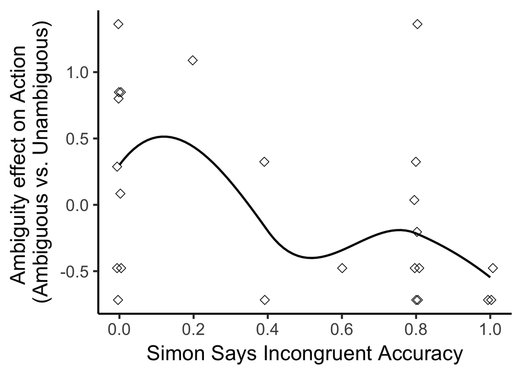